# Butterfly Data

## Checking

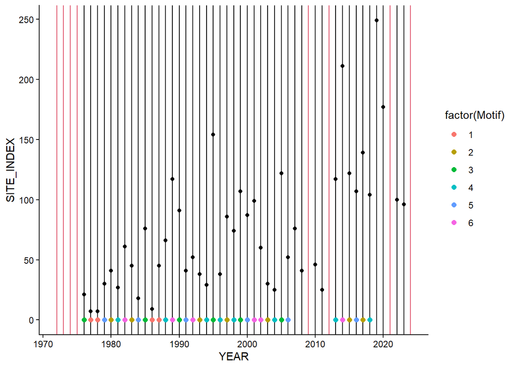

```r
test_motifs <- FindMotifs_NA_Robust(  Sp = 'Aglais io',
                                      Site= 'Woodwalton Farm',
                                      df =FiltDf_Compact)

FiltDf_Compact %>%
  filter(Site_Name == 'Woodwalton Farm',
         SPECIES == 'Aglais io') %>%
  ggplot(aes( x = YEAR))+
  geom_point(aes(y = SITE_INDEX))+
  geom_vline( xintercept = 1972:2024, col = 2)+
  geom_vline( aes(xintercept = YEAR))+
  geom_point(data=test_motifs, aes(y = 0,col = factor(Motif)), size = 2 )+
  theme_classic()
```

NB, where two of the three elements are present, there isn’t zero information, since certain motifs are ruled out. However, for simplicity, and given than the data is not all that patchy, this is not included for simplicity.

## Skipper Challenges

Differentiating small skippers and essex skippers is a challenge

In UKBMS they are summed into a single “Thymelicus lineola/sylvestris” category.

I will just use this, as they are ecologucally very similiar.

```r
FiltDf_Compact %>%
  filter(SPECIES     %in% c("Thymelicus lineola","Thymelicus lineola/sylvestris", "Thymelicus sylvestris")) %>%
  pivot_wider( names_from = SPECIES, values_from = SITE_INDEX) %>%
  arrange( Site, YEAR)
```

[output not shown]

### Mapping function across all site and species:

```r
SpSites<- distinct(FiltDf_Compact, Site_Name,SPECIES)

FullMotif_df <- map2_dfr( .f = FindMotifs_NA_Robust,
                          SpSites$SPECIES,
                          SpSites$Site_Name,
                          df =FiltDf_Compact )

## filtering to be just post 1980 due to earlier years having many species with very few sites.

FullMotif_df %>%
  count(Sp, YEAR ) %>%
  group_by(Sp) %>%
  summarise( min(n), mean(n))%>%
  arrange(  `min(n)` ) %>%
  print( n = 39)

FullMotif_df %>%
  count(Sp, YEAR ) %>%
  filter( n< 6) %>%
  count( YEAR)%>%
  print( n = 50)

### NB Two species are just too unusual to be reliable 'Euphydryas aurinia'  'Hamearis lucina'
## Left in the dataframe, but will filter before fitting

FullMotif_df %>%
  filter( YEAR >1979) %>%
  write_csv('Butterfly Data/FullMotif_df.csv')
```

### Motif Summary

```r
FullMotif_df <-read_csv('Butterfly Data/FullMotif_df.csv')
FullMotif_df %>%
  count( Motif)
```

```
## # A tibble: 6 × 2
##   Motif     n
##   <dbl> <int>
## 1     1 26914
## 2     2 20386
## 3     3 21257
## 4     4 20952
## 5     5 22131
## 6     6 26339
```

# Data Distribution Figure For Paper

### Underlying Map Data Prep

```r
## Boundary-Line Data from Ordnance Survey
## https://osdatahub.os.uk/data/downloads/open/BoundaryLine (Too large for github)
gb <- st_read( "bdline_gpkg_gb/Data/bdline_gb.gpkg",
  layer = "country_region")

gb_small <- st_crop( gb, xmin = 100000, xmax = 700000,
  ymin = 0,ymax = 460000)

# Simplify coastline/boundary
gb_small <- st_simplify( gb_small, dTolerance = 200,preserveTopology = TRUE)

# Save compactly
st_write( gb_small, "Map Data/GB_map_compact.gpkg")
```

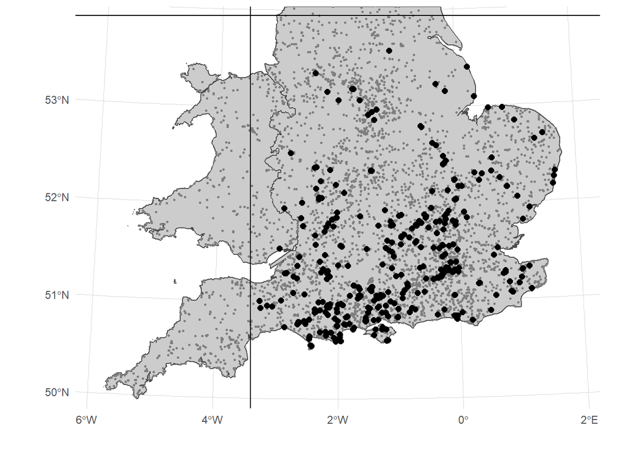

```r
LocationData %>%
  mutate( InData = Site_Name%in% unique(FullMotif_df$Site)) %>%
  mutate(InBox = Northing<450000 & Northing>0& Easting>300000 ) -> MapData

gb <- st_read("Map Data/GB_map_compact.gpkg")
ggplot(gb) +
  geom_sf(
    fill = "grey80",
    colour = "grey30",
    linewidth = 0.4
  ) +
  geom_point( data = MapData,
              aes( x = Easting, y = Northing,colour = InData),
              size = 0.5  ) +
  geom_point( data = filter(MapData, InData),
              aes( x = Easting, y = Northing,colour = InData),
              size = 2  ) +
  geom_hline( yintercept = 450000, linewidth = 0.5) +
  geom_vline( xintercept = 300000,linewidth = 0.5) +
  coord_sf(  crs = 27700,
             xlim = c(100000, 700000),
             ylim = c(0, 460000),
             expand = FALSE ) +
  scale_colour_manual( values = c("FALSE" = "grey50",  "TRUE" = "black"),
                       guide = "none") +
  xlab('')+  ylab('')+
  theme_minimal() +
  theme( panel.grid.major = element_line(colour = "grey85",linewidth = 0.25) )-> Map
Map
```

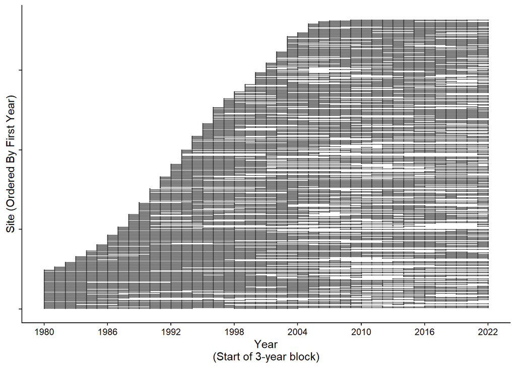

```r
FullMotif_df %>%
  group_by(Site)%>%
  summarise(FirstYear= min(YEAR))%>%
  arrange(FirstYear ) %>%
  mutate(O = rank( FirstYear,
                   ties.method = 'random') )  -> FirstYears

plot_df <- FullMotif_df %>%
  group_by(Site, YEAR) %>%
  summarise(n = n(), .groups = "drop") %>%
  left_join(FirstYears, by = "Site") %>%
  arrange(Site, YEAR) %>%
  group_by(Site) %>%
  mutate( next_YEAR = lead(YEAR)) %>%
  ungroup()

ggplot(plot_df, aes(y = O)) +
  geom_segment(data = subset(plot_df, next_YEAR == YEAR + 1),  # Lines only between consecutive years
               aes(x = YEAR, xend = next_YEAR, yend = O),
               linewidth = 0.2) +
  geom_point( aes(x = YEAR), size = 0.25) +
  scale_x_continuous(breaks = seq(1980, 2022, by = 6)) +
  theme_classic()  +
  theme(axis.text.y = element_blank())+
  ylab("Site (Ordered By First Year)") +
  xlab("Year\n(Start of 3-year block)")-> DataSiteTimeDistFig

DataSiteTimeDistFig
```

#### Further data summary

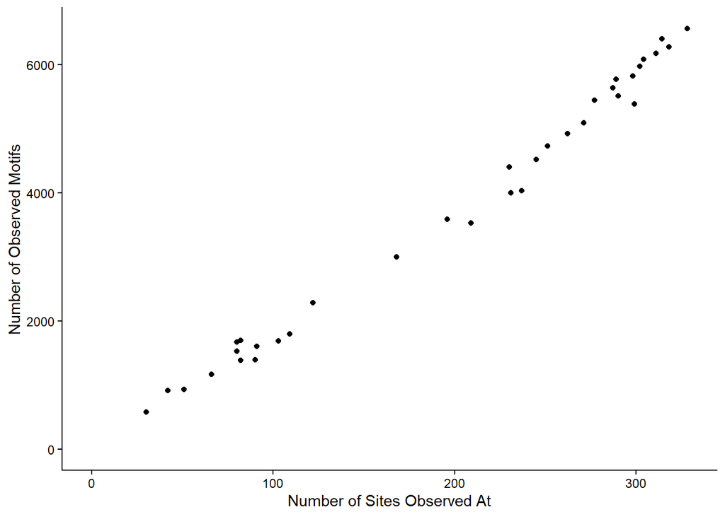

```r
N_SitePerSp <- FullMotif_df %>%
      filter( !(Sp %in% c('Euphydryas aurinia' , 'Hamearis lucina',# outliers of low data (less than 500)
                      "Thymelicus sylvestris", "Thymelicus lineola")) ) %>%
  count(Sp, Site) %>%
  count( Sp, name = 'N_SitePerSp')



N_ObsPerSp <- FullMotif_df %>%
      filter( !(Sp %in% c('Euphydryas aurinia' , 'Hamearis lucina',# outliers of low data (less than 500)
                      "Thymelicus sylvestris", "Thymelicus lineola")) ) %>%
  count(Sp, name = 'N_ObsPerSp' )


left_join(N_SitePerSp, N_ObsPerSp ) %>%
  ggplot( aes(  x = N_SitePerSp,N_ObsPerSp ))+
  geom_point()+
  theme_classic() +
  xlab( 'Number of Sites Observed At' )+
  ylab( 'Number of Observed Motifs')+
  scale_y_continuous(limits =c(0,NA))+
  scale_x_continuous(limits =c(0,NA)) -> DataAmountPlot
DataAmountPlot
```

### Combining into one

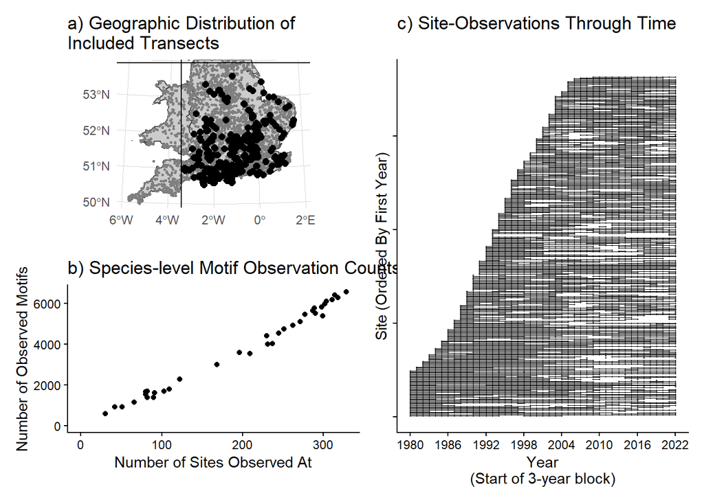

```r
final_plot <- ( (Map + labs(title = "a) Geographic Distribution of\nIncluded Transects")) /
  (DataAmountPlot + labs(title = "b) Species-level Motif Observation Counts"))
) + plot_layout(heights = c(1, 1)) | (DataSiteTimeDistFig + labs(title = "c) Site-Observations Through Time"))

final_plot
```

```r
ggsave( 'MS_Figs/ButterflyDataFig.png', height =6, width =8)
```

## A lot more than expected of motif 6 (double decline)

### Overall entropy per species

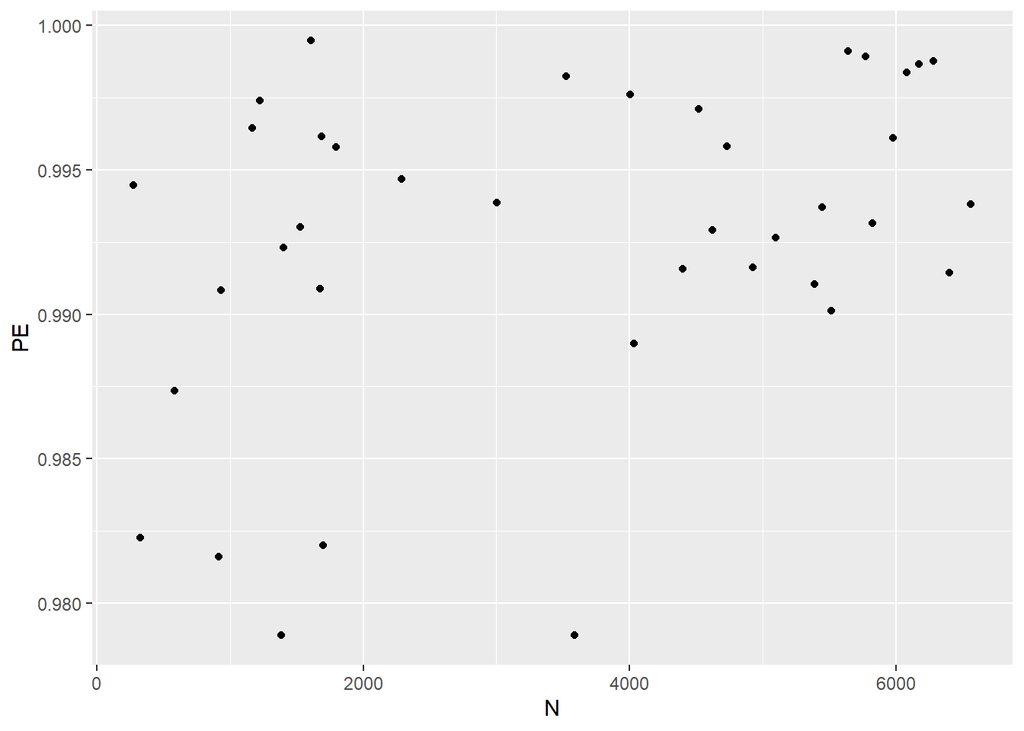

```r
FullMotif_df %>%
  count(Sp, Motif) %>%
  pivot_wider( names_from = Motif, values_from = n) %>%
  rowwise() %>%
  mutate( N = sum(c_across(`1` :`6` )),
          PE = { x <- c_across(`1` :`6` );
          -sum((x/N)*log((x/N))) / log(6)}
  ) -> OverallSp_PE


### Species with more observations demonstrate  higher PE...
### But counts large enough that this can't just be a sampling effect.
OverallSp_PE %>%
  ggplot( aes( y = PE, x = N))+
  geom_point()
```

### Species inspection

```r
Trends <- read_csv('Butterfly Data/SpeciesTrends/data/ukbmsspeciestrends2024.csv') %>%
  select(SCI_NAME , F_TRENDDETAIL )
OverallSp_PE %>%
  left_join(Trends, by=c('Sp' = 'SCI_NAME')) %>%
  arrange( PE)
```

```
## # A tibble: 39 × 10
## # Rowwise:
##    Sp                `1`   `2`   `3`   `4`   `5`   `6`     N    PE F_TRENDDETAIL
##    <chr>           <int> <int> <int> <int> <int> <int> <int> <dbl> <chr>
##  1 Lasiommata meg…   263   165   207   183   205   362  1385 0.979 Rapid decline
##  2 Coenonympha pa…   758   445   539   447   506   893  3588 0.979 Rapid decline
##  3 Polyommatus be…   213   136   111   123   130   203   916 0.982 Stable
##  4 Polyommatus co…   389   225   225   235   240   385  1699 0.982 Stable
##  5 Euphydryas aur…    83    46    48    39    50    59   325 0.982 Stable
##  6 Hipparchia sem…   119    75    98    69    99   125   585 0.987 Rapid decline
##  7 Celastrina arg…   915   565   554   593   604   801  4032 0.989 Rapid increa…
##  8 Polyommatus ic…  1192   738   834   718   952  1078  5512 0.990 Stable
##  9 Cupido minimus    211   128   152   123   159   161   934 0.991 Stable
## 10 Limenitis cami…   353   213   268   234   272   337  1677 0.991 Rapid decline
## # ℹ 29 more rows
```

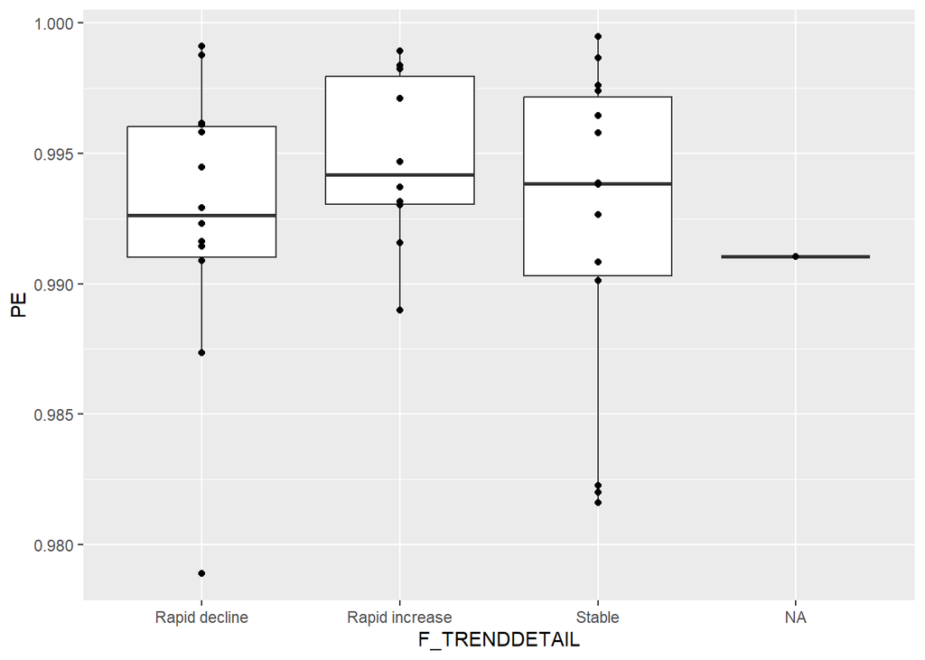

```r
OverallSp_PE %>%
  left_join(Trends, by=c('Sp' = 'SCI_NAME')) %>%
  ggplot( aes( x= F_TRENDDETAIL , y = PE))+
  geom_boxplot()+
  geom_point()
```

Looking overall, by UKBMS trend status, get a good range of PE across the categories

### Relative size of datasets for each species

```r
FullMotif_df %>%
  count(Sp, sort = TRUE)
```

```
## # A tibble: 39 × 2
##    Sp                     n
##    <chr>              <int>
##  1 Maniola jurtina     6559
##  2 Pyronia tithonus    6399
##  3 Pieris brassicae    6277
##  4 Pieris rapae        6172
##  5 Vanessa atalanta    6079
##  6 Ochlodes sylvanus   5975
##  7 Pararge aegeria     5821
##  8 Polygonia c-album   5770
##  9 Pieris napi         5639
## 10 Polyommatus icarus  5512
## # ℹ 29 more rows
```

```r
FullMotif_df %>%
  count(Sp, sort = TRUE) %>%
  tail()
```

```
## # A tibble: 6 × 2
##   Sp                        n
##   <chr>                 <int>
## 1 Colias croceus         1169
## 2 Cupido minimus          934
## 3 Polyommatus bellargus   916
## 4 Hipparchia semele       585
## 5 Euphydryas aurinia      325
## 6 Hamearis lucina         279
```